# analys

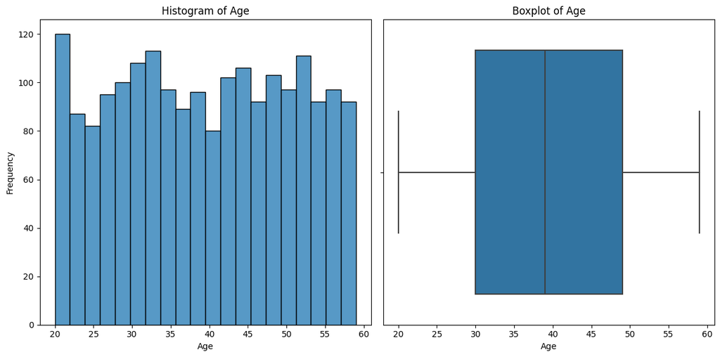

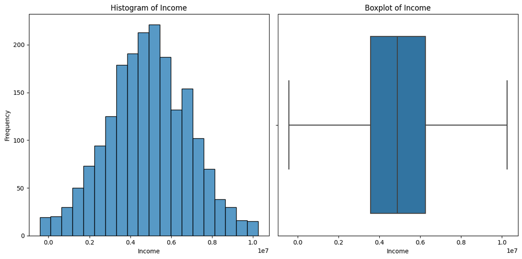

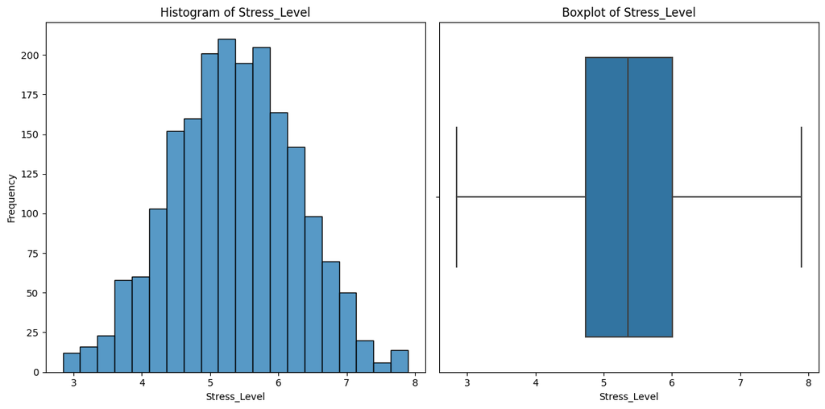

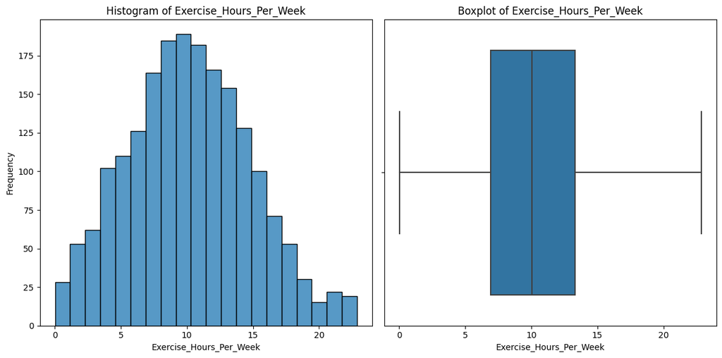

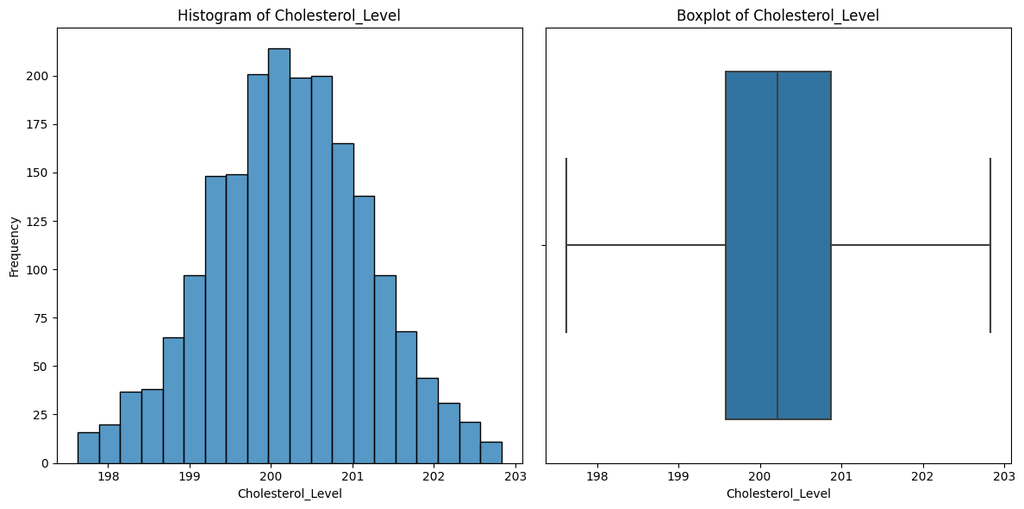

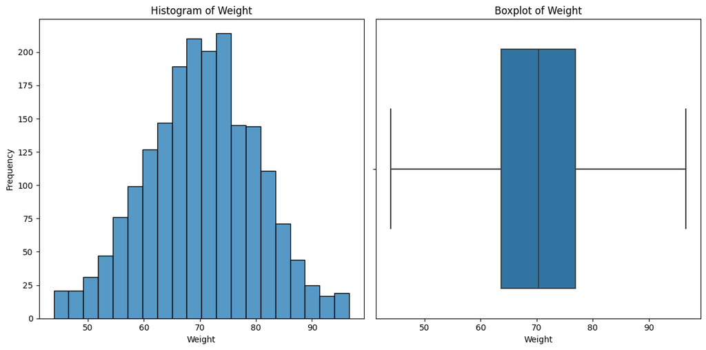

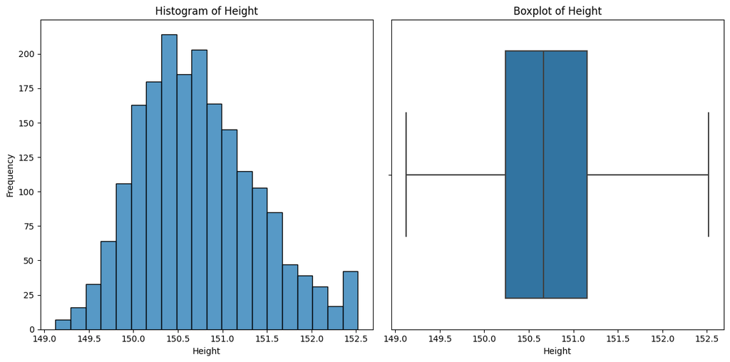

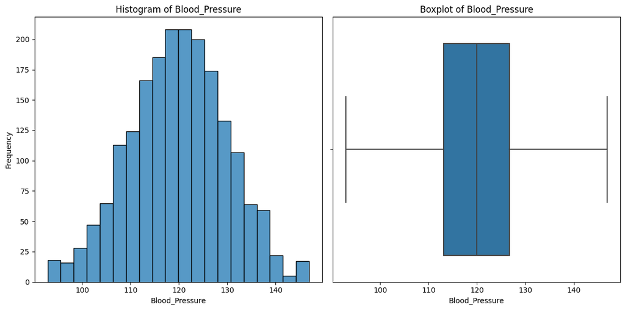

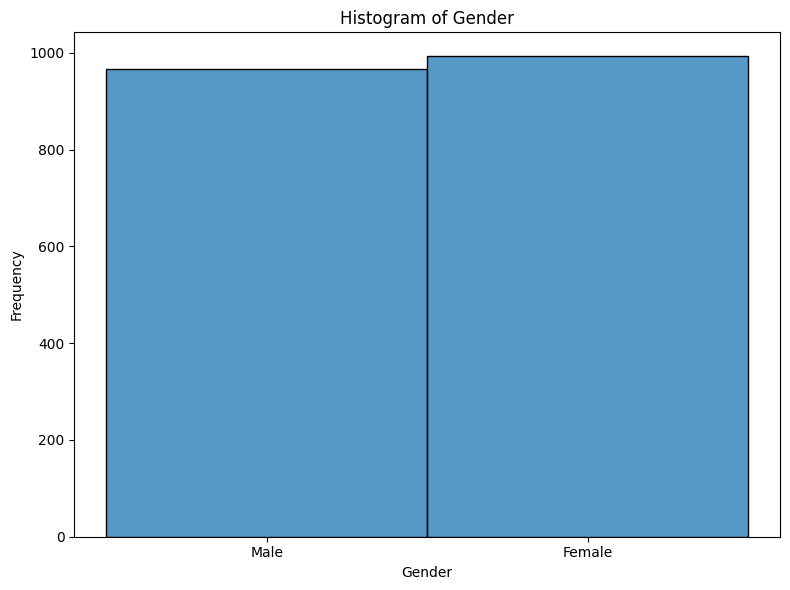

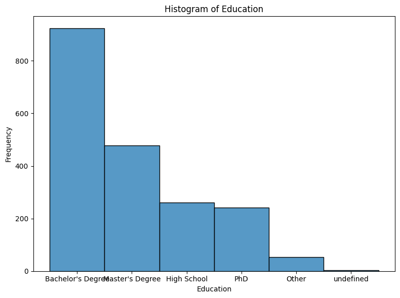

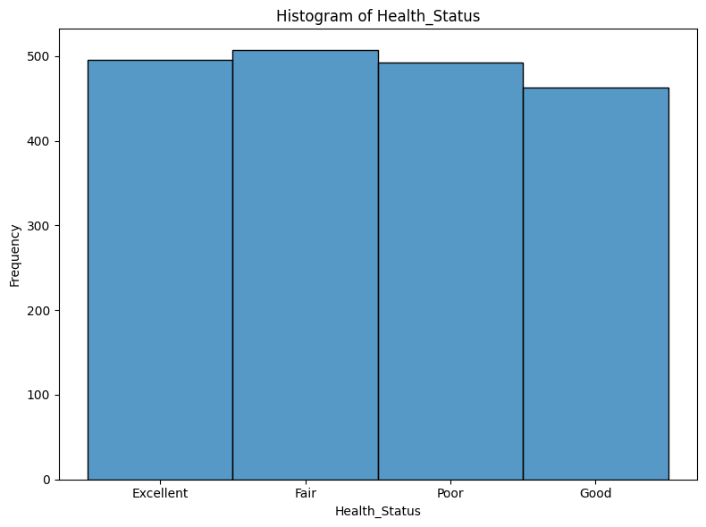

```python
import pandas as pd
import matplotlib.pyplot as plt
import seaborn as sns

# Membaca data dari CSV
# df = pd.read_csv("health.csv")

# # Menghilangkan kolom 'Unnamed: 0' jika ada
# if 'Unnamed: 0' in df.columns:
#     df = df.drop(columns=['Unnamed: 0'])

# # Menampilkan histogram dan boxplot untuk kolom numerik
# numeric_columns = df.select_dtypes(include=[np.number]).columns
for column in numeric_columns:
    plt.figure(figsize=(12, 6))

    # Histogram
    plt.subplot(1, 2, 1)
    sns.histplot(df[column], kde=False,bins=20)
    plt.title(f"Histogram of {column}")
    plt.xlabel(column)
    plt.ylabel("Frequency")

    # Boxplot
    plt.subplot(1, 2, 2)
    sns.boxplot(x=df[column])
    plt.title(f"Boxplot of {column}")
    plt.xlabel(column)

    plt.tight_layout()
    plt.show()

# Menampilkan histogram untuk kolom string
string_columns = df.select_dtypes(include=[object]).columns
for column in string_columns:
    plt.figure(figsize=(8, 6))

    # Histogram
    sns.histplot(df[column], discrete=True)
    plt.title(f"Histogram of {column}")
    plt.xlabel(column)
    plt.ylabel("Frequency")

    plt.tight_layout()
    plt.show()
```

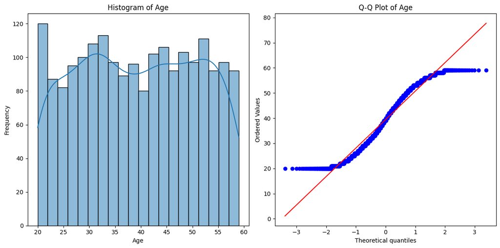

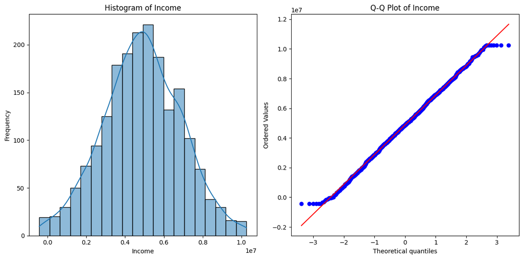

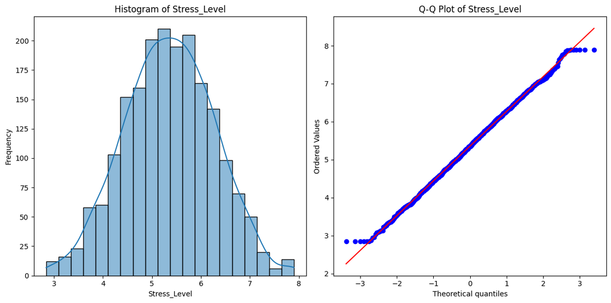

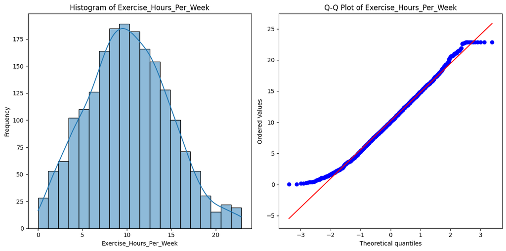

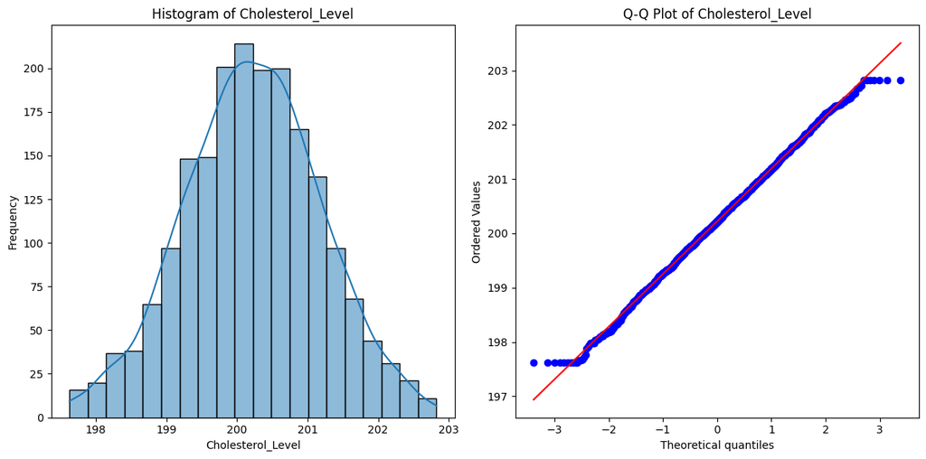

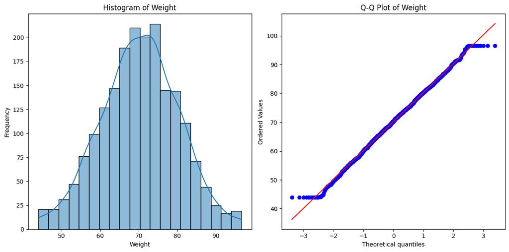

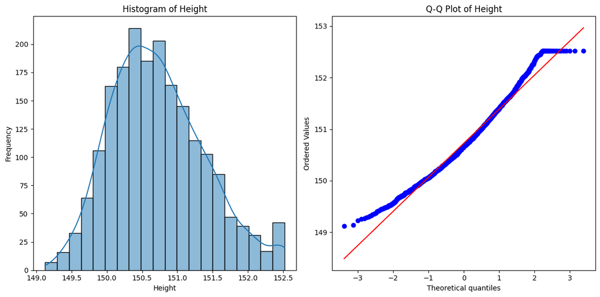

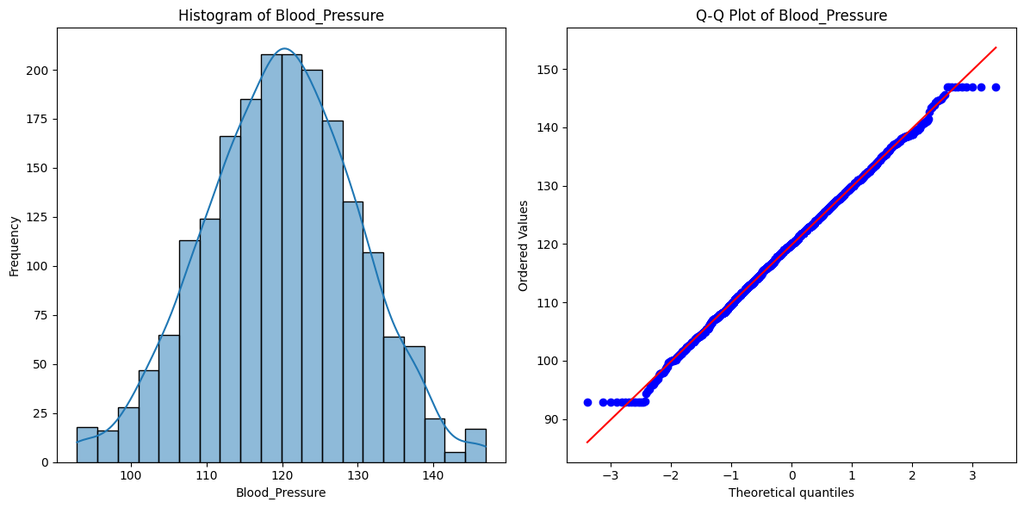

```
dari hasil visualisasi semua kolom  terdistribusi normal kecuali kolom `height` dan'Excercise_Hours_Per_Week' yang terdistribusi skewed kanan dan kolom `age` yang terdistribusi hampir uniform
```

```python
import seaborn as sns
import matplotlib.pyplot as plt
import scipy.stats as stats

for column in numeric_columns:
    plt.figure(figsize=(12, 6))

    # Histogram
    plt.subplot(1, 2, 1)
    # plt.hist(df[column],bins = 5, rwidth=0.5)
    sns.histplot(df[column], kde=True,bins = 20)
    plt.title(f"Histogram of {column}")
    plt.xlabel(column)
    plt.ylabel("Frequency")

    # Q-Q plot
    plt.subplot(1, 2, 2)
    stats.probplot(df[column].dropna(), dist="norm", plot=plt)
    plt.title(f"Q-Q Plot of {column}")

    plt.tight_layout()
    plt.show()

print("dari hasil visualisasi semua kolom  terdistribusi normal kecuali kolom `height` dan'Excercise_Hours_Per_Week' yang terdistribusi skewed kanan dan kolom `age` yang terdistribusi hampir uniform")
```

# 5 a. Langkah testing:

```
 1. h0 adalah μ berat badan bernilai 65
 2. h1 adalah μ berat badan bernilai lebih dari 65
 3. alpha = 0.05
 4. daerah kritis adalah μ > 65 nilai kritis 65. uji yang digunakan adalah z-test one sample(one-tailed)
 5. p-value = 7.80575604153455e-12(fungsi sendiri),7.805717763711249e-12(fungsi library)
 6. Kesimpulan:  Tolak H0 (rata-rata berat badan > 65 kg)
```

b. Langkah testing: 1. h0 adalah rata rata berat badan bernilai 120 2. h1 adalah rata rata berat badan tidak sama dengan 120 3. alpha = 0.05 4. daerah kritis adalah μ!=120. Uji yang digunakan adalah one sample z-test(two-tailed) 5. p-value = 0.8241364908938675(fungsi sendiri), 0.824136490893888(fungsi library) 6. Kesimpulan: Gagal Menolak H0 (rata-rata tekanan darah = 120 mmHg)

c. Langkah testing: 1.H0: μ = 15 jam 2.H1: μ ≠ 15 jam 3.α = 0.05 4.Uji statistik yang digunakan adalah one-sample z-test(two-tailed) Daerah kritis: μ!=15 5.p-value = 0.0(fungsi sendiri). 1.7051522502649754e-22(fugsi library) hal ini bereda karena ketilitian fungsi yang digunakan di library scipy berbeda dengan yang dibikin sendiri 6.Kesimpulan: Tolak H0 (rata-rata waktu olahraga != 15 jam)

d. Langkah testing: 1.H0 : proporsi pendapatan Rp 7.500.000 = 30% 2.H1 : proporsi pendapatan lebih dari Rp 7.500.000 !=30% 3.a = 0.05 4.Daerah kritis : Untuk proporsi, kita menggunakan Z-test. Karena kita menggunakan z-tests yang mengembalikan p-value langsung, daerah kritis akan berdasarkan p-value: Jika p-value < α, kita menolak H0. 5. 6.Kesimpulan: Tolak H0 (proporsi pendapatan lebih dari Rp 7.500.000,00 tidak sama dengan 30%)

Sample yang digunakan sebanyak 100 data

```python
import math
import numpy as np
import pandas as pd
from scipy import stats
from statsmodels.stats.weightstats import ztest
import statsmodels.api as sm

def mean(data):
    return sum(data) / len(data)

def variance(data, ddof=0):
    mean_value = mean(data)
    return sum((x - mean_value) ** 2 for x in data) / (len(data) - ddof)

def standard_deviation(data, ddof=0):
    return math.sqrt(variance(data, ddof))

def z_statistic(sample_data, population_mean, population_std_dev=None):
    sample_mean = mean(sample_data)
    n = len(sample_data)
    if population_std_dev is None:
        sample_std_dev = standard_deviation(sample_data, ddof=1)
        return (sample_mean - population_mean) / (sample_std_dev / math.sqrt(n))
    else:
        return (sample_mean - population_mean) / (population_std_dev / math.sqrt(n))

def p_value_z(z_stat, alternative='two-sided'):
    def normal_cdf(x):
        return (1.0 + math.erf(x / math.sqrt(2.0))) / 2.0

    if alternative == 'greater':
        return 1 - normal_cdf(z_stat)
    elif alternative == 'less':
        return normal_cdf(z_stat)
    else:  # two-sided
        if z_stat > 0:
            return 2 * (1 - normal_cdf(z_stat))
        else:
            return 2 * normal_cdf(z_stat)

def one_sample_z_test(data, population_mean, population_std_dev=None, alpha=0.05, alternative='two-sided'):
    z_stat = z_statistic(data, population_mean, population_std_dev)
    p_val = p_value_z(z_stat, alternative)

    print(f"Z-Statistic: {z_stat}")
    print(f"P-Value: {p_val}")

    if p_val < alpha:
        print("Tolak H0")
    else:
        print("Gagal Menolak H0")
```

```python
print("Fungsi Sendiri")
sample_weight = df['Weight'].sample(100, random_state=1)
mean_weight = mean(sample_weight)
std_weight = standard_deviation(sample_weight,1)
#fungsi sendiri
print(std_weight)
print(f"Uji Hipotesis 1: Apakah rata-rata berat badan lebih besar dari 65 kg?")
print("Mean weight" , mean_weight)
one_sample_z_test(sample_weight,65,std_weight,0.05,"greater")


print("\nFungsi library\n" )
#fungsi library
z_stat_weight, p_value_weight = ztest(sample_weight, value=65, alternative='larger')
print(sample_weight.std())
print(f"Mean Weight: {mean_weight}")
print(f"Z-statistic: {z_stat_weight}, P-value: {p_value_weight}")
print("Kesimpulan: ", "Tolak H0(rata-rata berat badan >65)") if p_value_weight < 0.05 else "Gagal menolak H0 (rata rata berat badan =65)"
print("\n")
```

```
Fungsi Sendiri
10.30309672908702
Uji Hipotesis 1: Apakah rata-rata berat badan lebih besar dari 65 kg?
Mean weight 71.9464500929958
Z-Statistic: 6.742099269421635
P-Value: 7.80575604153455e-12
Tolak H0

Fungsi library

10.30309672908702
Mean Weight: 71.9464500929958
Z-statistic: 6.742099269421635, P-value: 7.805717763711249e-12
Kesimpulan:  Tolak H0(rata-rata berat badan >65)
```

```python
print("Fungsi Sendiri")
sample_bp= df['Blood_Pressure'].sample(100, random_state=1)
mean_bp= mean(sample_bp)
std_bp = standard_deviation(sample_bp,1)
#fungsi sendiri
print(std_bp)
print(f"Uji Hipotesis 2: Apakah rata-rata tekanan darah lebih dari 120")
print("Mean bp" , mean_bp)
one_sample_z_test(sample_bp,120,std_bp,0.05)


print("\nFungsi library\n" )
#fungsi library
z_stat_bp, p_value_bp = ztest(sample_bp, value=120)
print(sample_bp.std())
print(f"Mean bp: {mean_bp}")
print(f"Z-statistic: {z_stat_bp}, P-value: {p_value_bp}")
print(f"Kesimpulan: Tolak H0(rata-rata tekanan darah tidak sama dengan 120)") if p_value_bp <0.05 else print("Gagal menolak H0 (rata rata tekanan darah sama dengan 120)")
print("\n")
```

```
Fungsi Sendiri
10.812307995623959
Uji Hipotesis 2: Apakah rata-rata tekanan darah lebih dari 120
Mean bp 120.24027962934346
Z-Statistic: 0.22222788089343157
P-Value: 0.8241364908938675
Gagal Menolak H0

Fungsi library

10.812307995623959
Mean bp: 120.24027962934346
Z-statistic: 0.22222788089340523, P-value: 0.824136490893888
Gagal menolak H0 (rata rata tekanan darah sama dengan 120)
```

```python
print("Fungsi Sendiri")
sample_excercise_hours = df['Exercise_Hours_Per_Week'].head(200).sample(100, random_state=1)
mean_excercise_hours = mean(sample_excercise_hours)
std_excercise_hours = standard_deviation(sample_excercise_hours,1)
#fungsi sendiri
print(std_excercise_hours)
print(f"Uji Hipotesis 3: Apakah rata-rata waktu olahraga per minggu tidak sama dengan 15 jam pada 200 individu pertama?")
print("Mean excercise_hours: " , mean_excercise_hours)
one_sample_z_test(sample_excercise_hours,15,std_excercise_hours,0.05)


print("\nFungsi library\n" )
#fungsi library
z_stat_excercise_hours, p_value_excercise_hours = ztest(sample_excercise_hours, value=15)
print(sample_excercise_hours.std())
print(f"Mean bp: {mean_excercise_hours}")
print(f"Z-statistic: {z_stat_excercise_hours}, P-value: {p_value_excercise_hours}")
print(f"Kesimpulan: Tolak H0(rata-rata olahraga per minggu tidak sama dengan 15 jam pada 200 individu pertama)") if p_value_excercise_hours <0.05 else "Gagal menolak H0 (rata rata olahraga per minggu sama dengan 15 jam)"
print('\n')
```

```
Fungsi Sendiri
4.677877488860884
Uji Hipotesis 3: Apakah rata-rata waktu olahraga per minggu tidak sama dengan 15 jam pada 200 individu pertama?
Mean excercise_hours:  10.435335824743364
Z-Statistic: -9.757981448052382
P-Value: 0.0
Tolak H0

Fungsi library

4.677877488860884
Mean bp: 10.435335824743364
Z-statistic: -9.757981448052382, P-value: 1.7051522502649754e-22
Kesimpulan: Tolak H0(rata-rata olahraga per minggu tidak sama dengan 15 jam pada 200 individu pertama)
```

```python
import math
import statsmodels.api as sm
def normal_cdf(x):
    """Cumulative distribution function for the standard normal distribution."""
    return (1.0 + math.erf(x / math.sqrt(2.0))) / 2.0
def z_statistic_proportion(sample_success, sample_size, population_proportion):
    sample_proportion = sample_success / sample_size
    return (sample_proportion - population_proportion) / math.sqrt((population_proportion * (1 - population_proportion)) / sample_size)

def p_value_z(z_stat, alternative='two-sided'):
    def normal_cdf(x):
        return (1.0 + math.erf(x / math.sqrt(2.0))) / 2.0

    if alternative == 'greater':
        return 1 - normal_cdf(z_stat)
    elif alternative == 'less':
        return normal_cdf(z_stat)
    else:  # two-sided
        if z_stat > 0:
            return 2 * (1 - normal_cdf(z_stat))
        else:
            return 2 * normal_cdf(z_stat)

def proportion_test(sample_success, sample_size, population_proportion, alpha=0.05, alternative='two-sided'):
    z_stat = z_statistic_proportion(sample_success, sample_size, population_proportion)
    p_val = p_value_z(z_stat, alternative)

    print("z_stat: ",z_stat)
    print("p_val: ", p_val)

    if p_val < alpha:
        print("Tolak H0")
    else:
        print("Gagal Menolak H0")


print("Fungsi sendiri")
sample_income = df['Income'].sample(100, random_state=1)
count_high_income = np.sum(sample_income > 7500000)
n = 100
p0 = 0.30

# Melakukan uji z-test untuk proporsi menggunakan fungsi yang dibuat sendiri
proportion_test(count_high_income, n, p0, alpha=0.05, alternative='two-sided')

print("Fungsi library")

test_stat, p_value_income = sm.stats.proportions_ztest(count_high_income, 100, p0,alternative = 'two-sided')
print(f"\nZ-statistic: {test_stat:.4f}, P-value: {p_value_income}")
print("Kesimpulan: ", "Tolak H0 (proporsi pendapatan lebih dari Rp 7.500.000,00 tidak sama dengan 30%) ") if  p_value_income < 0.05 else "Gagal menolak H0 (proporsi pendapatan lebih dari Rp 7.500.000,00 sama dengan 30%)"
```

```
Fungsi sendiri
z_stat:  -5.019011475427824
p_val:  5.193804760716958e-07
Tolak H0
Fungsi library

Z-statistic: -9.0144, P-value: 1.9793169794937494e-19
Kesimpulan:  Tolak H0 (proporsi pendapatan lebih dari Rp 7.500.000,00 tidak sama dengan 30%)
```

# 6 langkah langkah akan dibuat persub soal.

Sample pada data awal adalah 100 dan sampel pada data akhir adalah 100 a.

Daerah kritis adalah t-statistik di luar ±tα/2,df±tα/2,df, di mana df adalah derajat kebebasan.

5. p-value = 0.4773
6. gagal menolak H0 karena p-value lebih besar dari alpha.

```python
import math

def mean(data):
    return sum(data) / len(data)

def variance(data, ddof=0):
    mean_value = mean(data)
    return sum((x - mean_value) ** 2 for x in data) / (len(data) - ddof)

def standard_deviation(data, ddof=0):
    return math.sqrt(variance(data, ddof))

def z_statistic_two_sample(sample1, sample2):
    mean1, mean2 = mean(sample1), mean(sample2)
    n1, n2 = len(sample1), len(sample2)
    var1, var2 = variance(sample1, ddof=1), variance(sample2, ddof=1)

    pooled_std_error = math.sqrt(var1/n1 + var2/n2)
    return (mean1 - mean2) / pooled_std_error

def p_value_z(z_stat, alternative='two-sided'):
    def normal_cdf(x):
        return (1.0 + math.erf(x / math.sqrt(2.0))) / 2.0

    if alternative == 'greater':
        return 1 - normal_cdf(z_stat)
    elif alternative == 'less':
        return normal_cdf(z_stat)
    else:  # two-sided
        if z_stat > 0:
            return 2 * (1 - normal_cdf(z_stat))
        else:
            return 2 * normal_cdf(z_stat)

def two_sample_z_test(sample1, sample2, alpha=0.05, alternative='two-sided'):
    z_stat = z_statistic_two_sample(sample1, sample2)
    p_val = p_value_z(z_stat, alternative)

    print(f"Z-Statistic: {z_stat:.4f}")
    print(f"P-Value: {p_val}")

    if p_val < alpha:
        print("Tolak H0")
    else:
        print("Gagal Menolak H0")
```

```python
import statsmodels.api as sm
print("fungsi library")
# Misalkan data sudah diimport ke dalam dataframe `df`
n = len(df["Weight"])
midpoint = n // 2
early_data = df.iloc[:midpoint]
late_data = df.iloc[midpoint:]

# Sampel acak 50 dari masing-masing kelompok
early_sample = early_data['Weight'].sample(100, random_state=1)
late_sample = late_data['Weight'].sample(100, random_state=1)

# Uji z dua sampel menggunakan statsmodels
z_stat, p_value = sm.stats.ztest(early_sample, late_sample)
print(f"Z-Statistic: {z_stat:.4f}, P-Value: {p_value:.4f}")
if p_value < 0.05:
    print("Tolak H0")
else:
    print("Gagal Menolak H0")

print("fungsi buatan sendiri")

two_sample_z_test(early_sample, late_sample, alpha=0.05, alternative='two-sided')
```

```
fungsi library
Z-Statistic: 0.7107, P-Value: 0.4773
Gagal Menolak H0
fungsi buatan sendiri
Z-Statistic: 0.7107
P-Value: 0.47729927247595727
Gagal Menolak H0
```

```python
adjusted_late_income = late_data['Income'].sample(100,random_state= 1) + 1250000
print("fungsi library")
early_sample_income = early_data['Income'].sample(100,random_state=1)
t_stat, p_value = sm.stats.ztest(early_sample_income,adjusted_late_income)
print(f"t-statistic: {t_stat:.4f}, p-value: {p_value}")
if p_value < 0.05:
    print("tolak H0 ")
else:
    print("gagal menolak H0")
print("\n")
print("fungsi sendiri")
two_sample_z_test(early_sample_income,adjusted_late_income,0.05)
```

```
fungsi library
t-statistic: -5.6248, p-value: 1.856776134811572e-08
tolak H0


fungsi sendiri
Z-Statistic: -5.6248
P-Value: 1.85677613284696e-08
Tolak H0
```

c. 1. H0: Variansi tekanan darah individu yang lebih awal masuk data penelitian sama dengan variansi tekanan darah individu yang masuk baru saja (σ12=σ22). 2. H1: σ12≠σ22 3. a= 0.05 4. Uji statistik yang digunakan adalah uji variansi Bartlett. Daerah kritis adalah p-value < α. 5. p-value = 0.3908 6. gagal menolak H0

```python
from scipy.stats import bartlett
import math
from scipy.stats import t, f, norm

# Uji variansi Levene
early_sample_bp = early_data['Blood_Pressure'].sample(100,random_state=1)
late_sample_bp = late_data['Blood_Pressure'].sample(100,random_state=1)


stat, p_value = bartlett(early_sample_bp,late_sample_bp)
print(f"barlett statistic: {stat:.4f}, p-value: {p_value:.4f}")
if p_value < 0.05:
    print("tolak H0 ")
else:
    print("gagal menolak H0")

def f_statistic_two_sample(sample1, sample2):
    var1 = variance(sample1, ddof=1)
    var2 = variance(sample2, ddof=1)
    return var1 / var2

# Uji Hipotesis 3: Variansi Tekanan Darah

f_stat_bp = f_statistic_two_sample(early_sample_bp, late_sample_bp)
df1_bp = len(early_sample_bp) - 1
df2_bp = len(late_sample_bp) - 1
p_value_bp = 2 * min(f.cdf(f_stat_bp, df1_bp, df2_bp), 1 - f.cdf(f_stat_bp, df1_bp, df2_bp))

print(f"F-Statistic for Blood Pressure: {f_stat_bp:.4f}, P-Value: {p_value_bp:.4f}")
if p_value_bp < 0.05:
    print("Tolak H0: Variansi tekanan darah tidak sama.")
else:
    print("Gagal Menolak H0: Variansi tekanan darah sama.")
```

```
barlett statistic: 0.7365, p-value: 0.3908
gagal menolak H0
F-Statistic for Blood Pressure: 0.8411, P-Value: 0.3908
Gagal Menolak H0: Variansi tekanan darah sama.
```

d. 1. H0: Proporsi waktu olahraga lebih dari 8 jam per minggu pada data individu awal sama dengan proporsi pada data individu akhir (p1=p2). 2. H1: p1>p2p1>p2 3. a = 0.05 4. Uji statistik yang digunakan adalah uji proporsi dua sampel. Daerah kritis adalah z-statistik > zα. 5. p-value = 0.3788 6. gagal menolak H0.

```python
from statsmodels.stats.proportion import proportions_ztest

# Hitung jumlah individu yang olahraga lebih dari 8 jam per minggu

early_sample_exc = early_data['Exercise_Hours_Per_Week'].sample(100,random_state=1) > 8
late_sample_exc = late_data['Exercise_Hours_Per_Week'].sample(100,random_state=1)>8

n_early = len(early_sample_exc)
n_late = len(late_sample_exc)
count_early = early_sample_exc.sum()
count_late = late_sample_exc.sum()
# Uji proporsi dua sampel
count = np.array([count_early, count_late])
nobs = np.array([n_early, n_late])
stat, p_value = proportions_ztest(count, nobs, alternative='larger')
print(f"Z-statistic: {stat:.4f}, p-value: {p_value:.4f}")


if p_value < 0.05:
    print("tolak H0 ")
else:
    print("gagal menolak H0")


# Fungsi untuk uji proporsi dua sampel
def z_statistic_two_proportion(p1, n1, p2, n2):
    p = (p1 * n1 + p2 * n2) / (n1 + n2)
    z_stat = (p1 - p2) / math.sqrt(p * (1 - p) * (1/n1 + 1/n2))
    return z_stat

# Uji Hipotesis 4: Proporsi Waktu Olahraga

p1_early = early_sample_exc.mean()
p2_late = late_sample_exc.mean()
n1_early = len(early_sample_exc)
n2_late = len(late_sample_exc)

z_stat_exercise = z_statistic_two_proportion(p1_early, n1_early, p2_late, n2_late)
p_value_exercise = norm.cdf(z_stat_exercise)
print(f"Z-Statistic for Exercise Hours: {z_stat_exercise:.4f}, P-Value: {(1- p_value_exercise):.4f}")
if p_value_exercise < 0.05:
    print("Tolak H0: Proporsi waktu olahraga lebih dari 8 jam per minggu lebih besar pada data individu awal.")
else:
    print("Gagal Menolak H0: Proporsi waktu olahraga lebih dari 8 jam per minggu tidak lebih besar pada data individu awal.")
```

```
Z-statistic: 0.3086, p-value: 0.3788
gagal menolak H0
Z-Statistic for Exercise Hours: 0.3086, P-Value: 0.3788
Gagal Menolak H0: Proporsi waktu olahraga lebih dari 8 jam per minggu tidak lebih besar pada data individu awal.
```